# Determining Spatial Auto-Correlation with Nominal Variables through Join Count Statistics

Matthew Tralka

**Objective:** Use the join count statistics method to determine the special pattern of Urban and built-up lands in Maryland. Automate methodology using PySAL and seaborn.

**Data Source:** MODIS - MD extract, multi-polygon shapefile

**Join Count Statistics-** Methodology for determining the spatial autocorrelation for variables with nominal values. Two values for the variables, 0 or 1. Method measures where these two values touches, determining whether the values are clustered or dispersed.

*Null Hypothesis: Perfect random distributions*

*Check out the official PySAL documentation [here](https://pysal.org/esda/generated/esda.Join_Counts.html) and the PySAL Join Count blogpost [here](https://pysal.org/notebooks/explore/esda/joincounts.html)*

```python
import esda
import pandas as pd
import geopandas as gpd
from geopandas import GeoDataFrame
import libpysal as lps
import numpy as np
import matplotlib.pyplot as plt
import seaborn as sbn
%matplotlib inline
```

Import MD_LANDCOVER Shapefile and default CRS to NAD83 (ftUS) EPSG : 2248

```python
MD = gpd.read_file('MD_LANDCOVER/MD_LANDCOVER.shp')
MD = MD.to_crs("EPSG:2248")
```

Verify attribute schema

```python
print (MD)
```

```
    LANDCOVER  binary                                           geometry
0          14       0  POLYGON ((598070.376 766110.975, 624293.304 76...
1           4       0  POLYGON ((624293.304 765394.338, 650516.564 76...
2           4       0  POLYGON ((650516.564 764704.668, 676740.516 76...
3           4       0  POLYGON ((676740.516 764041.793, 702965.096 76...
4          14       0  POLYGON ((702965.096 763405.723, 729190.308 76...
..        ...     ...                                                ...
391         0       0  POLYGON ((1655400.412 134512.889, 1682267.543 ...
392         5       0  POLYGON ((1682267.543 134877.092, 1709134.381 ...
393         5       0  POLYGON ((1709134.381 135268.728, 1736000.804 ...
394        14       0  POLYGON ((1736000.804 135687.815, 1762866.834 ...
395         0       0  POLYGON ((1762866.834 136134.338, 1789732.415 ...

[396 rows x 3 columns]
```

Define how many cells of binary type 1 (urban and built-up land)

```python
binary_1 = binary == 1
sum(binary_1)
```

```
31
```

Define how many cells of binary type 0 (everything but urban and built-up land)

```python
binary_0 = binary == 0
sum(binary_0)
```

```
365
```

Visualize binary distributions

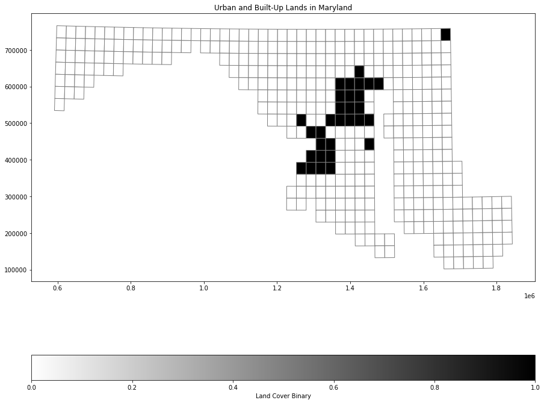

```python
plot = MD.plot(column='binary', legend=True, cmap='binary', edgecolor='grey', figsize=(15,15), legend_kwds = {'label' : "Land Cover Binary", 'orientation' : "horizontal"})
plot.set_title("Urban and Built-Up Lands in Maryland")
```

Calculate observed and expected (permutations: 999) join count

```python
wq = lps.weights.Queen.from_dataframe(MD)
wq.transfrom = 'b'
np.random.seed(12345)
join_count = esda.join_counts.Join_Counts(binary_1, wq)
```

Binary 1 to Binary 1 Count

```python
join_count.bb
```

```
64
```

Binary 0 to Binary 0 Count

```python
join_count.ww
```

```
1177
```

Binary 1 to Binary 0 Count

```python
join_count.bw
```

```
93
```

Total Join Counts

```python
join_count.bw + join_count.ww + join_count.bb
```

```
1334
```

Contingency Table of Observed Join Counts

```python
join_count.crosstab
```

| Neighbor Focal | W | B |
| --- | --- | --- |
| W | 1177 | 46 |
| B | 47 | 64 |

Contingency Table of Expected Random Join Counts

```python
join_count.expected
```

| Neighbor Focal | W | B |
| --- | --- | --- |
| W | 1122.152924 | 100.847076 |
| B | 101.847076 | 9.152924 |

Visualize mean expected and observed Binary 1 to Binary 1 counts

Black bar is mean **expected** Binary 1 to Binary 1 counts for a random distribution.

Red bar is the mean **observed** Binary 1 to Binary 1 counts

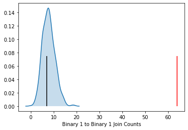

```python
sbn.kdeplot(join_count.sim_bb, shade=True)
plt.vlines(join_count.bb, 0, 0.075, color='r')
plt.vlines(join_count.mean_bb, 0,0.075)
plt.xlabel('Binary 1 to Binary 1 Join Counts')
```

As the mean observed real join count is higher than the expected random join count, there is a difference in real vs expected random distributions.

To determine if this difference is signifiant and reflective of spatial distributions, we can identify our pseudo-p value

```python
join_count.p_sim_bb
```

```
0.001
```

This value is below the standard significant level of .05.

We fail to support the null hypothesis. The Binary 1 values are significantly not randomly spatialy distributed.

As observed join count is greater than the expected join count, we assume the Binary 1 values clusters in space.

# Maryland urban and built-up land cover is signficiantly spatially clustered throughout the state